# 615-Midterm

YUE REN

2016年10月20日

## This project was supported by Qiu Yuan,Qin.

```r
library(tidyr)
library(plyr)
library(ggplot2)
library(dplyr)
library(reshape2)
library(data.table)
library(scales)
library(maps)
```

## County-level oil and gas production

```r
oilgascounty <- read.csv("C:/Users/ccren/Desktop/615mid/615mid/oilgascounty.csv")
```

### 1. Data summary and introduction

#### (a). Summary

```r
dim(oilgascounty)
```

```
## [1] 3109   35
```

```r
head(oilgascounty)
```

```
##   FIPS geoid Stabr    County_Name Rural_Urban_Continuum_Code_2013
## 1 1001  1001    AL Autauga County                               2
## 2 1003  1003    AL Baldwin County                               3
## 3 1005  1005    AL Barbour County                               6
## 4 1007  1007    AL    Bibb County                               1
## 5 1009  1009    AL  Blount County                               1
## 6 1011  1011    AL Bullock County                               6
##   Urban_Influence_2013 Metro_Nonmetro_2013 Metro_Micro_Noncore_2013
## 1                    2                   1                        2
## 2                    2                   1                        2
## 3                    6                   0                        0
## 4                    1                   1                        2
## 5                    1                   1                        2
## 6                    6                   0                        0
##   oil2000 oil2001 oil2002 oil2003 oil2004 oil2005 oil2006 oil2007 oil2008
```

[output cut: 27 more lines]

```r
colSums(is.na(oilgascounty)) #  check for whole cols filled with NA - variables without data
```

```
##                            FIPS                           geoid
##                               0                               0
##                           Stabr                     County_Name
##                               0                               0
## Rural_Urban_Continuum_Code_2013            Urban_Influence_2013
##                               0                               0
##             Metro_Nonmetro_2013        Metro_Micro_Noncore_2013
##                               0                               0
##                         oil2000                         oil2001
##                               0                               0
##                         oil2002                         oil2003
##                               0                               0
##                         oil2004                         oil2005
##                               0                               0
##                         oil2006                         oil2007
##                               0                               0
##                         oil2008                         oil2009
##                               0                               0
##                         oil2010                         oil2011
##                               0                               0
##                         gas2000                         gas2001
##                               0                               0
##                         gas2002                         gas2003
##                               0                               0
##                         gas2004                         gas2005
##                               0                               0
##                         gas2006                         gas2007
##                               0                               0
##                         gas2008                         gas2009
##                               0                               0
##                         gas2010                         gas2011
##                               0                               0
##                oil_change_group                gas_change_group
##                               0                               0
##            oil_gas_change_group
##                               0
```

```r
summary(oilgascounty)
```

```
##       FIPS           geoid           Stabr                 County_Name
##  Min.   : 1001   Min.   : 1001   TX     : 254   Washington County:  30
##  1st Qu.:19045   1st Qu.:19045   GA     : 159   Jefferson County :  25
##  Median :29213   Median :29213   VA     : 134   Franklin County  :  24
##  Mean   :30679   Mean   :30679   KY     : 120   Jackson County   :  23
##  3rd Qu.:46009   3rd Qu.:46009   MO     : 115   Lincoln County   :  23
##  Max.   :56045   Max.   :56045   KS     : 105   Madison County   :  19
##                                  (Other):2222   (Other)          :2965
##  Rural_Urban_Continuum_Code_2013 Urban_Influence_2013 Metro_Nonmetro_2013
##  Min.   :1.000                   Min.   : 1.000       Min.   :0.0000
##  1st Qu.:2.000                   1st Qu.: 2.000       1st Qu.:0.0000
##  Median :6.000                   Median : 5.000       Median :0.0000
##  Mean   :4.986                   Mean   : 5.224       Mean   :0.3734
##  3rd Qu.:7.000                   3rd Qu.: 8.000       3rd Qu.:1.0000
##  Max.   :9.000                   Max.   :12.000       Max.   :1.0000
##
##  Metro_Micro_Noncore_2013    oil2000             oil2001
##  Min.   :0.0000           Min.   :        0   Min.   :        0
##  1st Qu.:0.0000           1st Qu.:        0   1st Qu.:        0
##  Median :1.0000           Median :        0   Median :        0
##  Mean   :0.9518           Mean   :   389916   Mean   :   377786
##  3rd Qu.:2.0000           3rd Qu.:     7740   3rd Qu.:     8115
##  Max.   :2.0000           Max.   :208781424   Max.   :200867504
##
##     oil2002             oil2003             oil2004
##  Min.   :        0   Min.   :        0   Min.   :        0
##  1st Qu.:        0   1st Qu.:        0   1st Qu.:        0
##  Median :        0   Median :        0   Median :        0
##  Mean   :   364100   Mean   :   356800   Mean   :   350380
##  3rd Qu.:     8520   3rd Qu.:     7802   3rd Qu.:     8566
##  Max.   :198730576   Max.   :191390816   Max.   :185325184
##
##     oil2005             oil2006             oil2007
##  Min.   :        0   Min.   :        0   Min.   :        0
##  1st Qu.:        0   1st Qu.:        0   1st Qu.:        0
##  Median :        0   Median :        0   Median :        0
##  Mean   :   346858   Mean   :   348923   Mean   :   351030
##  3rd Qu.:     9468   3rd Qu.:     9785   3rd Qu.:    10633
##  Max.   :177573184   Max.   :170139232   Max.   :166179936
##
```

[output cut: 41 more lines]

```
##  Min.   :0.000e+00   H_Decline : 122    H_Decline : 155
##  1st Qu.:0.000e+00   H_Growth  : 107    H_Growth  : 174
##  Median :0.000e+00   Status Quo:2880    Status Quo:2780
##  Mean   :7.430e+06
##  3rd Qu.:6.045e+04
##  Max.   :1.167e+09
##
##  oil_gas_change_group
##  H_Decline : 212
##  H_Growth  : 218
##  Status Quo:2679
##
##
##
##
```

#### (b). Introduction the meanings of variables

State oil and gas production statistics were used to create a database of annual county-level production for 2000 through 2011. Data are available for onshore production in the lower 48 States only. Raw data for natural gas is for gross withdrawals, and oil data include natural gas liquids except for Colorado where the State reported them as natural gas withdrawals. Note that State-reported natural gas withdrawals were not available for Illinois or Indiana; these estimates were produced using geocoded wells and State total production reported by the EIA.

```
##                                   Description and Value Labels
## FIPS                              Five-digit Federal Information Processing Standard (FIPS) code (numeric)
## geoid                             FIPS code with leading zero (string)
## Stabr                             State abbreviation (string)
## County_Name                       County name (string)
## Rural_Urban_Continuum_Code_2013\t Rural-urban Continuum Code, 2013
## Urban_Influence_2013              Urban Influence Code, 2013
## Metro_Nonmetro_2013               Metro-nonmetro indicator 2013 (0=nonmetro, 1=metro)
## Metro_Micro_Noncore_2013          Metro-Micro-Noncore indicator 2013 (0=nonmetro noncore, 1=nonmetro micropolitan, 2=metropolitan)
## oil2000, oil2001, ..., oil2011    Annual gross withdrawals (barrels) of crude oil, for the year specified in the variable name (2000 through 2011)
## gas2000, gas2001, ..., gas2011    Annual gross withdrawals (1,000 cubic feet) of natural gas, for the year specified in the variable name (2000 through 2011)
## oil_change_group                  Categorical variable based upon change in the dollar value of oil production, 2000-11. Values are H_Growth (>=$20 million), H_Decline (<=-$20 million), Status Quo (change between +/- $20 million)
## gas_change_group                  Categorical variable based upon change in the dollar value of natural gas production, 2000-11. Values are H_Growth (>=$20 million), H_Decline (<=-$20 million), Status Quo (change between +/- $20 million)
## oil_gas_change_group              Categorical variable based on the change in the dollar value of the sum of oil and natural gas production, 2000-11. Values are H_Growth (>=$20 million), H_Decline (<=-$20 million), Status Quo (change between +/- $20 million)
```

### 2.Clean the data

#### (a). Natural gas and oil production in the lower 48 states, by metropolitan status, 2000-2011

```r
# gas production
gas <- subset(oilgascounty,select = c(County_Name,Metro_Micro_Noncore_2013,
 Stabr,gas2000:gas2011,gas_change_group))
```

```r
# oil production
oil <- subset(oilgascounty,select = c(County_Name, Stabr,Metro_Micro_Noncore_2013,
oil2000:oil2011,oil_change_group))
```

```r
others<-subset(oilgascounty,select=c(FIPS,County_Name:Metro_Nonmetro_2013))
```

```r
gas<-melt(gas,id.vars = c("County_Name","Stabr","Metro_Micro_Noncore_2013","gas_change_group"),variable.name = "year",value.name="gas")
gas$year<-substr(gas$year,4,7)
```

```r
oil<-melt(oil,id.vars =  c("County_Name","Stabr","Metro_Micro_Noncore_2013","oil_change_group"),variable.name = "year",value.name="oil")
oil$year<-substr(oil$year,4,7)
```

```r
oil<-data.table(oil)
stabroil<-oil[,sum(oil),by=list(year,Metro_Micro_Noncore_2013)]
head(stabroil)
```

```
##    year Metro_Micro_Noncore_2013        V1
## 1: 2000                        2 526140409
## 2: 2000                        0 400474798
## 3: 2000                        1 285633964
## 4: 2001                        2 510634367
## 5: 2001                        0 384830609
## 6: 2001                        1 279072174
```

```r
#total gas indifferent state and different year
gas<-data.table(gas)
stabrgas<-gas[,sum(gas),by=list(year,Metro_Micro_Noncore_2013)]
head(stabrgas)
```

```
##    year Metro_Micro_Noncore_2013         V1
## 1: 2000                        2 5115068744
## 2: 2000                        0 5827077583
## 3: 2000                        1 4780251817
## 4: 2001                        2 5089285321
## 5: 2001                        0 5911317461
## 6: 2001                        1 4990082304
```

### 3.Plot

#### From 2000 to 2011, onshore gross withdrawals of natural gas in the lower 48 States increased by about 47 percent, reaching historic highs in every year after 2006. Over the same period, withdrawals of oil increased by 11 percent, with much of that growth occurring between 2007 and 2011. Rural counties (nonmetro noncore) accounted for almost all of the growth in oil production and a large share of the growth in gas production. For natural gas, several metropolitan areas—notably the Fort Worth area in Texas—also contributed to the growth in production. County-level indicators of the degree of rurality are included in the data file.

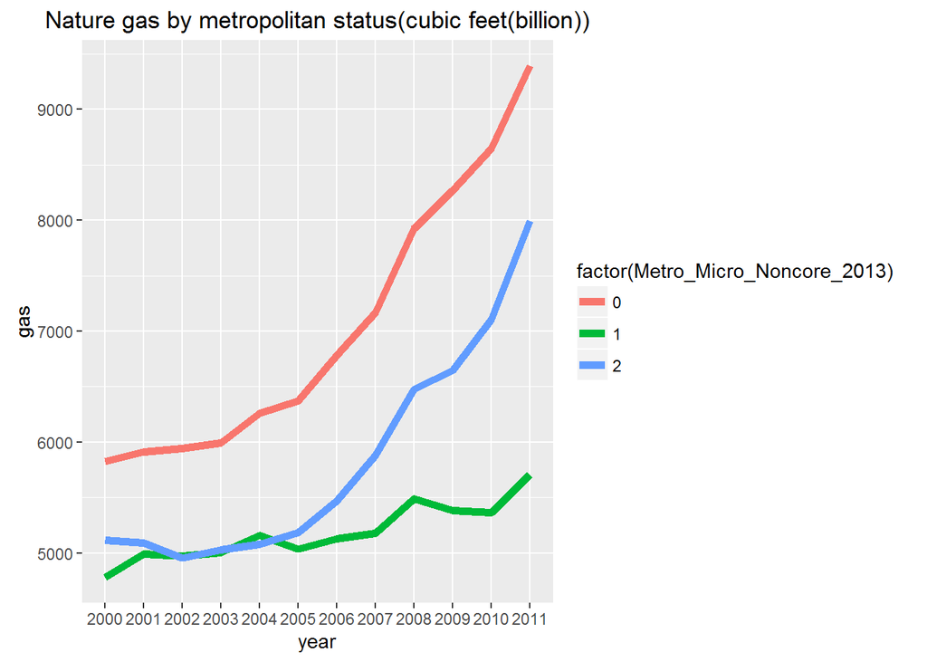

```r
#plot
# gas
stabrgas<-data.table(stabrgas)
stabrgas$V1<-stabrgas$V1/10^6
ggplot(stabrgas,aes(x=year,y=V1))+
  geom_line(aes(color=factor(Metro_Micro_Noncore_2013),group=Metro_Micro_Noncore_2013),lwd=2)+
  ylab("gas")+geom_smooth()+ggtitle("Nature gas by metropolitan status(cubic feet(billion))")
```

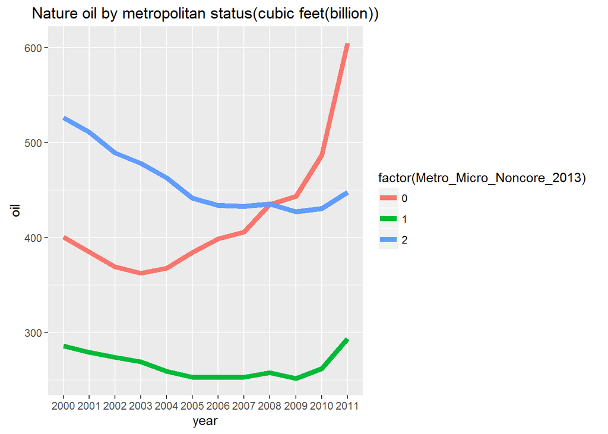

```r
#oil
stabroil<-data.table(stabroil)
stabroil$V1<-stabroil$V1/10^6
ggplot(stabroil,aes(x=year,y=V1))+
  geom_line(aes(color=factor(Metro_Micro_Noncore_2013),group=Metro_Micro_Noncore_2013),lwd=2)+
  ylab("oil")+geom_smooth()+ggtitle("Nature oil by metropolitan status(cubic feet(billion))")
```

### Change the variables:

```r
# oil_gas_group
oilgasgroup<-function(x){
  for(i in 1:length(x)){
    if(x[i]=="H_Growth"){
      x[i]<-">=20"
    }else if(x[i]=="H_Decline"){
      x[i]<-"<=-20"
    }else{
      x[i]<-"-20/+20"
    }
  }
  i=i+1
  return(x)
}

oil$oil_change_group<-as.character(oil$oil_change_group)
oil$oil_change_group<-oilgasgroup(oil$oil_change_group)

gas$gas_change_group<-as.character(gas$gas_change_group)
gas$gas_change_group<-oilgasgroup(gas$gas_change_group)
```

### 4.Barplots

#### We aggregate the gas production from year 2000-2011 by different Urban influence level.

```r
gas_2 <- subset(oilgascounty,select=c(County_Name, Stabr,Urban_Influence_2013,gas2000:gas2011,gas_change_group))

gas_2<-melt(gas_2,id.vars = c("County_Name","Stabr","Urban_Influence_2013","gas_change_group"),variable.name = "year",value.name="gas")

gas_2 <- data.table(gas_2)
stabrgas_2<-aggregate(as.numeric(gas_2$gas),by=list(gas_2$Urban_Influence_2013),FUN=sum)
head(stabrgas_2)
```

```
##   Group.1           x
## 1       1 20226396448
## 2       2 49807515942
## 3       3  4311178920
## 4       4  5403723815
## 5       5 22444259821
## 6       6 17589619412
```

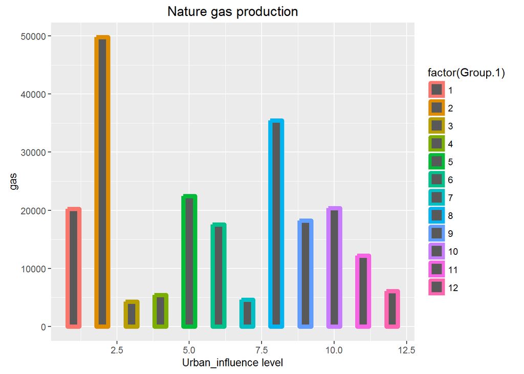

```r
q <- ggplot(stabrgas_2,aes(x=Group.1,y=x))+
  geom_bar(stat="identity",width=0.4,aes(color=factor(Group.1),group=Group.1),lwd=2)+xlab("Urban_influence level")+
  ylab("gas")+ggtitle("Nature gas production")

q <- q+scale_y_continuous(labels = function(x)x/1000000)+theme(axis.title=element_text(size = 10))
q
```

#### Oil #### We aggregate the oil production from year 2000-2011 by different Urban influence level.

```r
oil_2 <- subset(oilgascounty,select=c(County_Name, Stabr,Urban_Influence_2013,oil2000:oil2011,gas_change_group))

oil_2 <- melt(oil_2,id.vars =c("County_Name","Stabr","Urban_Influence_2013","gas_change_group"),variable.name = "year",value.name="oil")

oil_2 <- data.table(oil_2)
stabroil_2<-aggregate(as.numeric(oil_2$oil),by=list(oil_2$Urban_Influence_2013),FUN=sum)
head(stabroil_2)
```

```
##   Group.1          x
## 1       1 1068507997
## 2       2 4446219764
## 3       3  240911525
## 4       4  297523863
## 5       5 1046363979
## 6       6  957652856
```

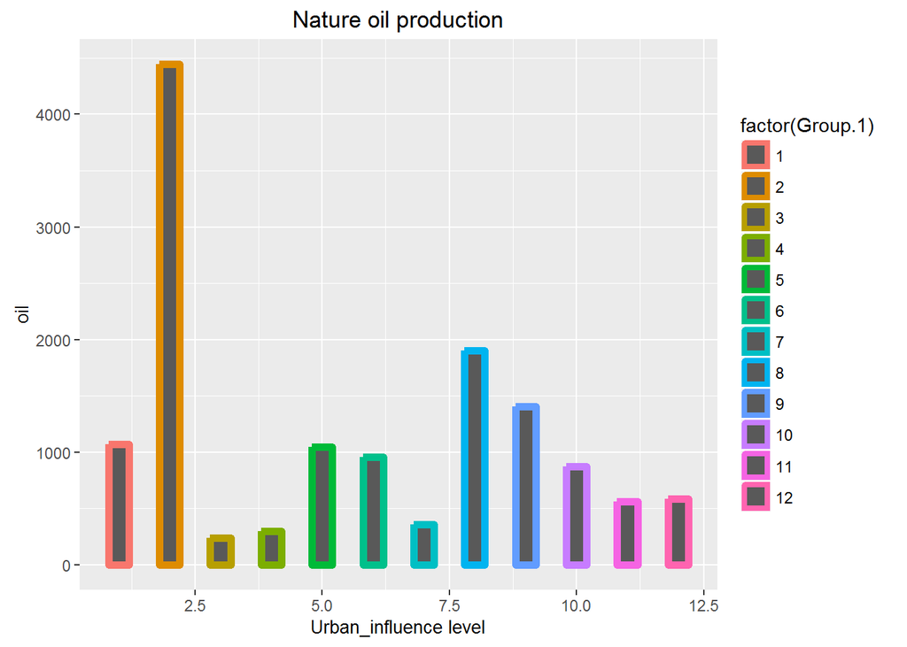

```r
p <- ggplot(stabroil_2,aes(x=Group.1,y=x))+
  geom_bar(stat="identity",width=0.4,aes(color=factor(Group.1),group=Group.1),lwd=2)+xlab("Urban_influence level")+
  ylab("oil")+ggtitle("Nature oil production")

p <- p+scale_y_continuous(labels = function(x)x/1000000)+theme(axis.title=element_text(size = 10))
p
```

### 5.Barplots by states

```r
oil <- data.table(oil)
gas <- data.table(gas)
stateoil<-oil[,mean(oil),by=list(Stabr)]
stategas<-gas[,mean(gas),by=list(Stabr)]
```

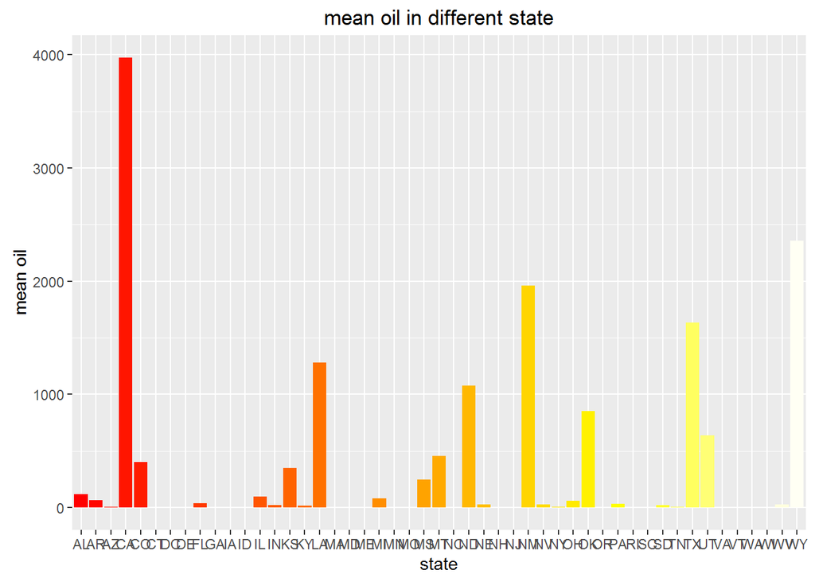

```r
ggplot(stateoil,aes(x=Stabr,y=V1/10^3))+geom_bar(stat="identity",fill=heat.colors(49))+ylab("mean oil")+xlab("state")+ggtitle("mean oil in different state")
```

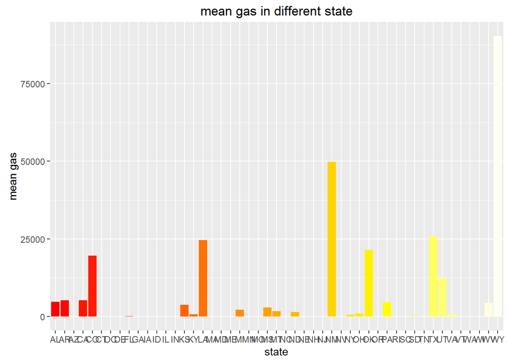

```r
ggplot(stategas,aes(x=Stabr,y=V1/10^3))+geom_bar(stat="identity",fill=heat.colors(49))+ylab("mean gas")+xlab("state")+ggtitle("mean gas in different state")
```